# Monitoring sozialer Determinanten der Covid19 Epidemie

Niels Michalski

29. April 2020

# Info

Hier sollen aktuelle Informationen zur Ausbruchsentwicklung der Covid-19 Pandemie in Deutschland für den internen Austausch gesammelt werden.

# Regionale Ungleichheiten

## Regionale Fallzahlen

Regionale Fallzahlen

Regionale Todeszahlen

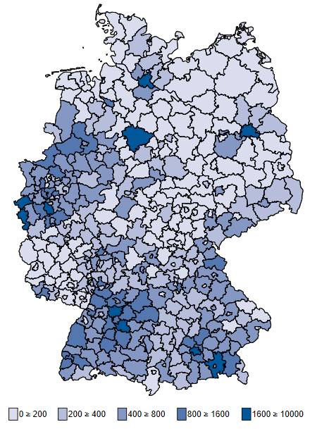

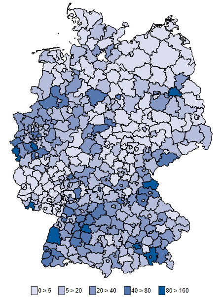

Stand 30. April 2020

## Regionale Fallzahlen (pro 100k Einwohner)

Regionale Fallzahlen pro 100k Einwohner

Regionale Todeszahlen pro 100k Einwohner

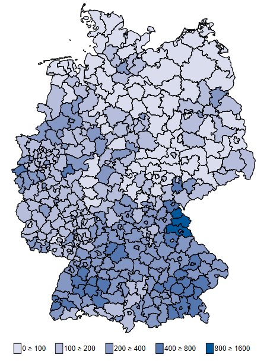

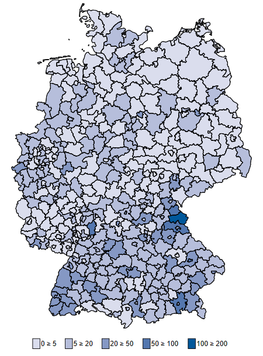

Stand 30. April 2020

## Krude Fallsterblichkeit (CFR)

Regionale Fallsterblichkeit

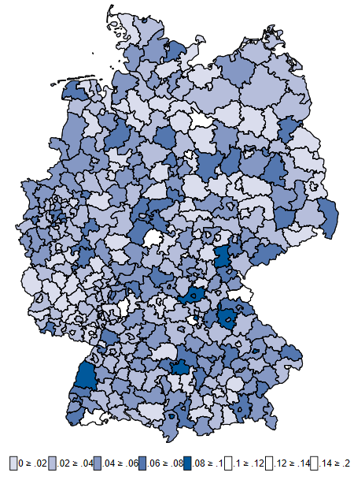

Stand 30. April 2020

# Informationen über das regionale Ausbruchsgeschehen

Hier sollten Informationen zum Verlauf des regionalen Ausbruchsgeschehens gesammelt werden

## Baden Württemberg

### Bad Rappenau

17.April 2020 [Ende der Quarantäne im Alpenland Altenheim](https://www.rnz.de/nachrichten/sinsheim_artikel,-bad-rappenau-quarantaene-im-alpenland-altenheim-nach-sechs-wochen-aufgehoben-update-_arid,502459.html)

## Schleswig-Holstein

### Nordfriesland

27. April 2020 [Grillparty in Nordfriesland](https://www.spiegel.de/panorama/nordfriesland-neue-corona-faelle-nach-illegaler-grillparty-a-e40f8468-ec97-40f3-9d8a-2d954abe320e)

# Linksammlungen

## Regionales Monitoring des Ausbruchsgeschehens

Covid-19 Small Area Monitor von der Uni Bielefeld und Uni Heidelberg:  
[Covidmonitor](http://covidmonitor.de/)

## R und R Markdown Tutorials

Workflow Guide für die Arbeit mit RStudio, RMarkdown und GitHub:  
[Happy Git with R](https://happygitwithr.com/index.html)

Markdown Guide:  
[R Markdown: The Definitive Guide](https://bookdown.org/yihui/rmarkdown/)

# About this page

BAM!